# Kansas Voter Registration File - 2026-05-04

Earl F Glynn

2026-05-11

Script to perform quality checks and to produce frequency counts of fields in the Kansas voter registration file.

**History**

- Convert very old R script to markdown and tidyverse | 2019-01-26
- Check for Geary County “tab problem” removed after problem since 2006 | 2026-01-12

**Output Files**

**State**

- `Kansas-Fixed.txt` - fix tab problem, header consistency
- `Kansas-Updated.txt` - add additional useful variables for analysis
- `Kansas-Counts-Age-yyyy-mm-dd.xlsx`
- `Kansas-Counts-State-yyyy-mm-dd.xlsx`
- `Kansas-Crosstab-BirthYear-by-BirthMonth-yyyy-mm-dd.xlsx`
- `Kansas-Crosstab-RegisterYear-by-RegisterMonth-yyyy-mm-dd.xlsx`
- `Kansas-Registrations-By-Year-and-Month-yyyy-mm-dd.svg`
- `Kansas-Explore-Name-Duplicates-yyyy-mm-dd.xlsx`
- `Kansas-Households-Address-to-Explore-for-Many-Voters-yyyy-mm-dd.xlsx`
- `Kansas-Households-Mail-to-Explore-for-Many-Voters-yyyy-mm-dd.xlsx`

**County**

- `Kansas-Counts-County-yyyy-mm-dd.xlsx`
- `Kansas-County-Voter-Election-Code-Summary-yyyy-mm-dd.xlsx`

**Precinct**

- `Kansas-Counts-Precinct-yyyy-mm-dd.xlsx`

**Voter**

- `Kansas-Election-Codes-by-Voter-yyyy-mm-dd.txt`
- `Kansas-Explore-Name-Duplicates-yyyy-mm-dd.xlsx`
- `Kansas-Voters-Missing-District-Info-yyyy-mm-dd.xlsx`

**Election Code**

- `Election-Codes-yyyy-mm-dd.xlsx` [Move to `Voter-Election-Codes-0-Setup`]

**Data Fields**

- `Kansas-Field-Length-Summary-yyyy-mm-dd.xlsx`
- `Counts` folder with CSV file of frequency counts for each of ~90 fields

# 1 Backstage

## 1.2 Constants

```r
EXCEL_LIMIT <- 2^20
```

Use 5-year census intervals (except for interval 18-19)

```r
ageBreaks <- 5 * 3:17
ageBreaks[1] <- 18
```

[1] 18 20 25 30 35 40 45 50 55 60 65 70 75 80 85

```r
ageIntervals <-
  c(paste(ageBreaks[-length(ageBreaks)], ageBreaks[-1]-1, sep = "-"),
    paste0(ageBreaks[length(ageBreaks)], "+"))
ageIntervals[1] <- "18-19"
```

[1] “18-19” “20-24” “25-29” “30-34” “35-39” “40-44” “45-49” “50-54” “55-59” “60-64” [11] “65-69” “70-74” “75-79” “80-84” “85+”

## 1.3 Packages

```r
library(tidyverse)
```

```r
library(writexl)
```

```r
library(kableExtra)
```

```r
library(stringi)     # stri_enc_toutf8
```

```r
library(lubridate)   # date/time functionsrlang
library(gplots)      # heatmap.2
```

```r
library(scales)      # comma
```

## 1.4 Helper Function

```r
Show <- function(data, caption="", bigMark="",
                 height = NULL, width = NULL, ...)
{
  data                                       |>
  kable("html", caption=caption,
        format.args=list(big.mark=bigMark))  |>
  kable_styling(bootstrap_options=c("striped", "bordered", "condensed"),
                position="left",
                full_width=FALSE, ...)       |>
  scroll_box(height = height, width = width)
}
```

## 1.5 ggplot theme

```r
theme_set(theme_minimal() +

          theme(axis.text             = element_text(size = 10),
                axis.title            = element_text(size = 14),

                legend.position       = "bottom",

                plot.title            = element_text(color = "steelblue1",  size = 16, face = "bold"),
                plot.caption          = element_text(hjust = c(0.0,1.0),
                                                     size = 10),
                plot.caption.position = "plot",

                plot.title.position   = "plot",

                strip.background      = element_rect(fill = "aliceblue"),
                strip.text            = element_text(size = 14),

                title                 = element_text(size = 14)))
```

```r
COLOR_BAR     <- "skyblue"
COLOR_OUTLINE <- "grey80"
```

## 1.6 County Info

```r
CountyLabel <-
  tibble(
    County = c(
      'Allen',      'Anderson',    'Atchison',    'Barber',      'Barton',      'Bourbon',
      'Brown',      'Butler',      'Chase',       'Chautauqua',  'Cherokee',    'Cheyenne',
      'Clark',      'Clay',        'Cloud',       'Coffey',      'Comanche',    'Cowley',
      'Crawford',   'Decatur',     'Dickinson',   'Doniphan',    'Douglas',     'Edwards',
      'Elk',        'Ellis',       'Ellsworth',   'Finney',      'Ford',        'Franklin',
      'Geary',      'Gove',        'Graham',      'Grant',       'Gray',        'Greeley',
      'Greenwood',  'Hamilton',    'Harper',      'Harvey',      'Haskell',     'Hodgeman',
      'Jackson',    'Jefferson',   'Jewell',      'Johnson',     'Kearny',      'Kingman',
      'Kiowa',      'Labette',     'Lane',        'Leavenworth', 'Lincoln',     'Linn',
      'Logan',      'Lyon',        'Marion',      'Marshall',    'McPherson',   'Meade',
      'Miami',      'Mitchell',    'Montgomery',  'Morris',      'Morton',      'Nemaha',
      'Neosho',     'Ness',        'Norton',      'Osage',       'Osborne',     'Ottawa',
      'Pawnee',     'Phillips',    'Pottawatomie','Pratt',       'Rawlins',     'Reno',
      'Republic',   'Rice',        'Riley',       'Rooks',       'Rush',        'Russell',
      'Saline',     'Scott',       'Sedgwick',    'Seward',      'Shawnee',     'Sheridan',
      'Sherman',    'Smith',       'Stafford',    'Stanton',     'Stevens',     'Sumner',
      'Thomas',     'Trego',       'Wabaunsee',   'Wallace',     'Washington',  'Wichita',
      'Wilson',     'Woodson',     'Wyandotte'),

    CountyAbbr =  c(
      'AL', 'AN', 'AT', 'BA', 'BT', 'BB', 'BR', 'BU', 'CS', 'CQ', 'CK', 'CN',
      'CA', 'CY', 'CD', 'CF', 'CM', 'CL', 'CR', 'DC', 'DK', 'DP', 'DG', 'ED',
      'EK', 'EL', 'EW', 'FI', 'FO', 'FR', 'GE', 'GO', 'GH', 'GT', 'GY', 'GL',
      'GW', 'HM', 'HP', 'HV', 'HS', 'HG', 'JA', 'JF', 'JW', 'JO', 'KE', 'KM',
      'KW', 'LB', 'LE', 'LV', 'LC', 'LN', 'LG', 'LY', 'MN', 'MS', 'MP', 'ME',
      'MI', 'MC', 'MG', 'MR', 'MT', 'NM', 'NO', 'NS', 'NT', 'OS', 'OB', 'OT',
      'PN', 'PL', 'PT', 'PR', 'RA', 'RN', 'RP', 'RC', 'RL', 'RO', 'RH', 'RS',
      'SA', 'SC', 'SG', 'SW', 'SN', 'SD', 'SH', 'SM', 'SF', 'ST', 'SV', 'SU',
      'TH', 'TR', 'WB', 'WA', 'WS', 'WH', 'WL', 'WO', 'WY')
  )
```

# 2 Character Quality Check

Check for unusual characters using `CharCount` utility from [github](https://github.com/EarlGlynn/CharacterCount). This shows the count of the 256 possible 8-bit bytes in the file. Look for changes from recent files.

The `CharCount` table will confirm whether the field separator is a tab (x09) vs a comma (x2C), and identify possible problem characters

Screen shot of running CharCount is saved to file `CharCount.png` for inclusion here.

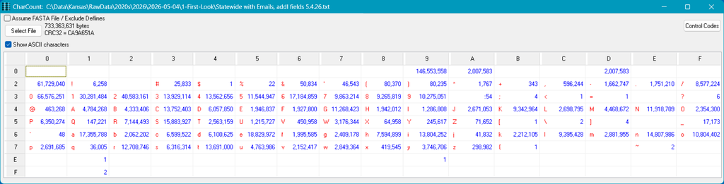

The number of problem characters is now fairly low compared to past years.

Problems can include x’E1’ and x’F1’. Failure to fix these characters can cause problems.

See use of `iconv` below.

# 3 Raw data file

## 3.1 Parameters

```r
cat("Raw Data: ",       params$RAW_VOTER_FILE,
    "\nUpdated File: ", params$UPDATED_VOTER_FILE,
    "\nElection Date (for age computations): ", params$ELECTION_DATE, "\n")
```

```
Raw Data:  Statewide with Emails, addl fields 5.4.26.txt
Updated File:  Kansas-Updated.txt
Election Date (for age computations):  2026-08-04
```

## 3.2 Delimiter Check

The Kansas statewide file has had problems in the parsability of records for various reasons for many years.

The Geary County “tab problem” from 2006 was finally resolved in 2025.

So, let’s check that are records parse consistently.

Parameters to `count.fields`:

- Without `comment.char` override, records with # characters are problems.
- Without `quote` override, records with apostrophes or quotation marks are problems.

```r
counts <- tibble(fieldCounts = count.fields(params$RAW_VOTER_FILE,
                                            sep="\t",
                                            comment.char="",
                                            quote=""))
```

```r
freqCounts <-
  counts                                |>
  group_by(fieldCounts)                 |>
  summarize(n = n(), .groups = "drop")  |>
  ungroup()

freqCounts |>
    Show(bigMark = ",")
```

| fieldCounts | n |
| --- | --- |
| 73 | 1 |
| 74 | 2,007,582 |

For unknown reasons, the Kansas voter file has a header that is tab separated, but data records with fields that are tab terminated.

R complains about this mismatch. Currently, R will add the extra separator to the end of the last field of the record, which will need to be fixed.

## 3.3 Read fixed file

```r
voters <- read_delim(params$RAW_VOTER_FILE, "\t",
                     quote = "",
                     comment = "",
                     na = character(),  # some people might have names of "NA"
                     col_types = cols(.default = "c"),
                     progress = FALSE)
```

```r
dim(voters)
```

```
[1] 2007582      73
```

Caused by “terminator” vs separator:

R now leaves the extra tab “separator” as part of the last data field

```r
voters[1:3, ncol(voters)]
```

```
# A tibble: 3 × 1
  district_sd
  <chr>
1 "SD257\t"
2 "SD257\t"
3 "SD257\t"
```

Remove unwanted, extra separator in last column

```r
voters <-
  voters |>
  mutate(district_sd = str_replace(district_sd, "\\t", ""))
```

```r
voters[1:3, ncol(voters)]
```

```
# A tibble: 3 × 1
  district_sd
  <chr>
1 SD257
2 SD257
3 SD257
```

```r
glimpse(voters)
```

```
Rows: 2,007,582
Columns: 73
$ db_logid                       <chr> "Allen", "Allen", "Allen", "Allen", "Al…
$ cde_registrant_status          <chr> "A   ", "A   ", "A   ", "A   ", "A   ",…
$ cde_name_title                 <chr> "", "", "", "", "", "", "", "", "", "",…
$ text_name_first                <chr> "Craig", "Georgia", "James", "Samya", "…
$ text_name_middle               <chr> "Melton", "Mae", "Carson", "India", "L"…
$ text_name_last                 <chr> "Abbott", "Abbott", "Abbott", "Abram", …
$ cde_name_suffix                <chr> "", "", "", "", "", "", "", "", "", "",…
$ cde_gender                     <chr> "M   ", "F   ", "F   ", "F   ", "F   ",…
$ text_registrant_id             <chr> "4482236", "4472179", "6393408", "61732…
$ registrant_text_email          <chr> "", "", "", "", "", "", "", "", "", "JN…
$ text_res_address_nbr           <chr> "9", "9", "104", "815", "72", "103", "1…
$ text_res_address_nbr_suffix    <chr> "", "", "", "", "", "", "", "", "", "",…
$ cde_street_dir_prefix          <chr> "", "", "", "N   ", "", "S   ", "S   ",…
```

[output cut: 60 more lines]

### 3.3.1 Parties

Verify current political parties (new ones added in 2024):

Recode missing party to `Unaffiliated`

```r
table(voters$desc_party, useNA = "ifany")
```

```
      Democratic      Libertarian No Labels Kansas       Republican
          494896            23770             7220           893204
    Unaffiliated    United Kansas
          587354             1138
```

### 3.3.2 Genders

```r
table(voters$cde_gender, useNA = "ifany")
```

```
           F       M       U
   3269 1042011  952605    9697
```

# 4 Cleanup / Fixups / Add new variables

Osage County congressional district problems from 2024-2025 fixed in 2026.

## 4.1 Wrong State Senate District

- Wilson County KS0014 → KS0012

```r
voters |>
  filter(db_logid %in% c("Wilson")) |>
  group_by(db_logid)   |>
  count(district_ks )  |>
  Show()
```

| db_logid | district_ks | n |
| --- | --- | --- |
| Wilson | KS0014 | 5063 |

### 4.1.1 Wilson County

[Senate District 12](https://kslegislature.gov/li/s/pdf/district_maps/district_map_s_012.pdf) map shows it contains Wilson County]

[Senate District 14](https://kslegislature.gov/li/s/pdf/district_maps/district_map_s_014.pdf) does not contain Wilson County.

```r
target <- which(voters$db_logid == "Wilson")
voters$district_ks[target] <- "KS0012"
length(target)
```

```
[1] 5063
```

Verify fix

```r
voters |>
  filter(db_logid %in% c("Wilson")) |>
  group_by(db_logid)   |>
  count(district_ks )  |>
  Show()
```

| db_logid | district_ks | n |
| --- | --- | --- |
| Wilson | KS0012 | 5063 |

## 4.2 troubleshoot

verify fix

[output not shown]

```r
voters |>
  select(text_name_middle) |>    # verify fix
  mutate(
          text_name_middle = stri_enc_toutf8(text_name_middle, validate = FALSE),
          text_name_middle = str_squish(text_name_middle),
          is_valid_utf8    = stri_enc_isutf8(text_name_middle)
        )  |>
  filter(!is_valid_utf8 | is.na(is_valid_utf8)) |>
  print()
```

```
# A tibble: 0 × 2
# ℹ 2 variables: text_name_middle <chr>, is_valid_utf8 <lgl>
```

[output not shown]

```r
voters |>
  select(text_name_last)                      |>
  mutate(
          text_name_last = stri_enc_toutf8(text_name_last, validate = FALSE),
          text_name_last = str_squish(text_name_last),
          is_valid_utf8  = stri_enc_isutf8(text_name_last)
        )  |>
  filter(!is_valid_utf8 | is.na(is_valid_utf8)) |>
  print()
```

```
# A tibble: 0 × 2
# ℹ 2 variables: text_name_last <chr>, is_valid_utf8 <lgl>
```

## 4.3 Other cleanup

Problem names

```r
voters |>
  filter(!stri_enc_isutf8(text_name_middle)) |>
  pull(text_name_middle)
```

```
[1] "Ren\xe1"
```

```r
voters |>
  filter(!stri_enc_isutf8(text_name_last)) |>
  pull(text_name_last)
```

```
[1] "Arreola-P\xe9rez"    "Hipolito Brise\xf1o" "Salda\xf1a-Tovar"
```

Get rid of leading/trailing/extra blanks in many fields. Should be fixed in state file.

```r
x <-
  voters |>
  rename(County = db_logid)           |>   # `County` should never have been `db_logid`
  inner_join(CountyLabel, by = "County") |>
  relocate(CountyAbbr, .after = County)
```

```r
votersModified <-
  voters                                 |>
  rename(County = db_logid)              |>   # `County` should never have been `db_logid`
  inner_join(CountyLabel, by = "County") |>
  relocate(CountyAbbr, .after = County)  |>   # add county abbreviation
  mutate(
          cde_registrant_status       = str_trim(cde_registrant_status) |>
                                        str_to_upper(),  # Lower case happened once

          # many fields have leading blanks to trim -- should probably trim all fields
          cde_name_title              = str_trim(cde_name_title),
          text_name_first             = str_squish(text_name_first),

                                        # Total kludge here.  Problems shown above
          text_name_middle            =  stri_enc_toutf8(text_name_middle, validate = FALSE) |>
                                         str_squish(),

          text_name_last              = stri_enc_toutf8(text_name_last, validate = FALSE)    |>
                                        str_squish(),

          cde_name_suffix             = str_trim(cde_name_suffix),

          registrant_text_email       = str_trim(registrant_text_email),

          text_res_address_nbr        = str_trim(text_res_address_nbr),
          text_res_address_nbr_suffix = str_trim(text_res_address_nbr_suffix),
          cde_street_dir_prefix       = str_trim(cde_street_dir_prefix),
          text_street_name            = str_squish(text_street_name),
          cde_street_type             = str_trim(cde_street_type),
          cde_street_dir_suffix       = str_trim(cde_street_dir_suffix),
          cde_res_unit_type           = str_trim(cde_res_unit_type),
          text_res_unit_nbr           = str_trim(text_res_unit_nbr),
          text_res_zip5               = str_trim(text_res_zip5),
          text_res_zip4               = str_trim(text_res_zip4),

          text_mail_address1          = str_squish(text_mail_address1),  # also remove extra internal spaces
          text_mail_address2          = str_squish(text_mail_address2),
          text_mail_address3          = str_squish(text_mail_address3),
          text_mail_address4          = str_squish(text_mail_address4),
          text_mail_city              = str_squish(text_mail_city),
          cde_mail_state              = str_trim(cde_mail_state),
          text_mail_zip5              = str_trim(text_mail_zip5),
          text_mail_zip4              = str_trim(text_mail_zip4),

          text_res_carrier_rte        = str_trim(text_res_carrier_rte),
          text_mail_carrier_rte       = str_trim(text_mail_carrier_rte),

          text_phone_exchange         = str_trim(text_phone_exchange),
          text_phone_last_four        = str_trim(text_phone_last_four),

          text_election_code_1        = str_trim(text_election_code_1),
          text_election_code_2        = str_trim(text_election_code_2),
          text_election_code_3        = str_trim(text_election_code_3),
          text_election_code_4        = str_trim(text_election_code_4),
          text_election_code_5        = str_trim(text_election_code_5),
          text_election_code_6        = str_trim(text_election_code_6),
          text_election_code_7        = str_trim(text_election_code_7),
          text_election_code_8        = str_trim(text_election_code_8),
          text_election_code_9        = str_trim(text_election_code_9),
          text_election_code_10       = str_trim(text_election_code_10),
          polling_place_text_zip5     = str_trim(polling_place_text_zip5),
          polling_place_text_zip4     = str_trim(polling_place_text_zip4),
          district_jd                 = str_trim(district_jd),
          district_sd                 = str_trim(district_sd),

          text_res_physical_address = str_trim(text_res_physical_address),

          ## Add useful derived fields
          phone                     = paste(text_phone_area_code,
                                            text_phone_exchange,
                                            text_phone_last_four, sep = "-"),
          cde_gender                = str_trim(cde_gender),
          cde_gender                = recode(
                                             cde_gender,
                                             .missing = "U"
                                            ),

          desc_party                = if_else(desc_party  == "",    # Missing -> "Unaffilated"
                                              "Unaffiliated",
                                              str_trim(desc_party)),
          desc_party                = recode(desc_party,
                                             .missing = "Unaffiliated"),

          Party                     = case_match(desc_party,
                                                  "Democratic"       ~ "D",
                                                  "Libertarian"      ~ "L",
                                                  "No Labels Kansas" ~ "N",   # new in 2024
                                                  "Republican"       ~ "R",
                                                  "Unaffiliated"     ~ "U",
                                                  "United Kansas"    ~ "K"    # new in 2024
                                                ),

          commissioner =paste0(CountyAbbr, "-", district_cc),   # Make unique statewide

          precinct_text_designation = str_trim(precinct_text_designation),
          precinct_text_name        = str_trim(precinct_text_name),  # needed for some counties
          precinct                  = paste(CountyAbbr,              # Make unique statewide
                                            precinct_text_name, precinct_text_designation,
                                            sep = "|"),

          precinct_part_text_designation = str_trim(precinct_part_text_designation),
          precinct_part_text_name        = str_trim(precinct_part_text_name),
          precinctPart                   = paste(CountyAbbr, precinct_part_text_name,
                                                 precinct_part_text_designation, sep = "|"),

          # Kansas voter roll often has 100+ near-duplicate name entries, often at the same address.
          nameHash = paste(   # used to be hash, but now let's use verbose string
                            CountyAbbr,
                            text_name_last,
                            text_name_first,
                            text_name_middle,
                            cde_name_suffix,
                            cde_gender,
                            mdy(date_of_birth),
                            sep = "|"
                           ),

          # Households
          addressHousehold = paste(CountyAbbr,
                                   text_res_city,
                                   text_res_zip5,
                                   text_res_address_nbr,
                                   text_res_address_nbr_suffix,
                                   cde_street_dir_prefix, text_street_name, cde_street_type,
                                   cde_res_unit_type, text_res_unit_nbr,
                                   text_res_zip4,
                                   sep = "|"),
          mailHousehold    = paste(
                                   text_mail_city,
                                   text_mail_zip5,
                                   text_mail_address1,
                                   text_mail_address2,
                                   text_mail_address3,
                                   text_mail_address4,
                                   cde_mail_state,
                                   text_mail_zip4,
                                   sep = "|"),

          # Registration
          RegisterDate     = mdy(date_of_registration),
          RegisterYear     = lubridate::year(RegisterDate),       # Use for cleanup
          RegisterMonth    = lubridate::month(RegisterDate),
          Registered       = (RegisterDate %--% lubridate::ymd(params$ELECTION_DATE)) / years(1),

          # Birthdate / Age
          BirthDate        = mdy(date_of_birth),
          BirthYear        = lubridate::year(BirthDate),          # Use for cleanup
          BirthMonth       = lubridate::month(BirthDate),
          Age              = round((BirthDate %--% lubridate::ymd(params$ELECTION_DATE)) / years(1)),
          AgeInterval      = cut(Age,
                                 breaks = c(ageBreaks, Inf),
                                 right = FALSE,
                                 labels = ageIntervals),
          AgeRegistered    = round( as.numeric( mdy(date_of_registration)  -
                                                mdy(date_of_birth) ) / 365.25, 2),

          DayOfLeapYear    = paste0( str_sub(date_of_birth, 1, 6),  "2024" ) |> mdy() |>  yday()  # Fairly random distribution?
        )
```

```r
dim(votersModified)
```

```
[1] 2007582      93
```

```r
write_tsv(votersModified, params$UPDATED_VOTER_FILE)
```

```r
save(votersModified,
     file = paste0(params$STATE, "-Voters-Updated-", params$VOTER_FILE_DATE, ".rda"))
```

# 5 Stats for State

## 5.1 Status

```r
table(votersModified$cde_registrant_status, useNA = "ifany")
```

```
      A       I
1734169  273413
```

## 5.2 Party

```r
table(votersModified$desc_party, useNA = "ifany")
```

```
      Democratic      Libertarian No Labels Kansas       Republican
          494896            23770             7220           893204
    Unaffiliated    United Kansas
          587354             1138
```

```r
table(votersModified$Party, useNA = "ifany")
```

```
     D      K      L      N      R      U
494896   1138  23770   7220 893204 587354
```

## 5.3 Gender

```r
table(votersModified$cde_gender, useNA = "ifany")
```

```
              F       M       U
   3269 1042011  952605    9697
```

## 5.4 Age

### 5.4.1 Too young?

BirthDate needed to be 18 on election day

```r
ymd(params$ELECTION_DATE) - years(18)
```

```
[1] "2008-08-04"
```

```r
tooYoung <-
  votersModified |>
  filter(BirthDate > ymd(params$ELECTION_DATE) - years(18))

if (nrow(tooYoung) > 0)
{
  write_xlsx(tooYoung,
             paste0(params$STATE, "-Age-Too-Young-", params$VOTER_FILE_DATE, ".xlsx"))
}

dim(tooYoung)
```

```
[1]  0 93
```

BirthDate range for too young

```r
c( min(tooYoung$BirthDate), min(tooYoung$BirthDate))
```

```
[1] "Inf" "Inf"
```

### 5.4.2 Stats

```r
fivenum(votersModified$Age)
```

```
[1]  18  34  49  66 226
```

```r
table(votersModified$Age, useNA = "ifany")
```

```
   18    19    20    21    22    23    24    25    26    27    28    29    30
 2300 14424 24780 28129 31716 32722 34508 34861 35955 35019 35734 34222 34308
   31    32    33    34    35    36    37    38    39    40    41    42    43
34150 34201 33785 34314 34027 35043 34208 33720 33028 33543 33928 33696 33140
   44    45    46    47    48    49    50    51    52    53    54    55    56
33865 33321 33346 31624 29851 29881 28528 27822 27769 26774 27364 28933 30667
   57    58    59    60    61    62    63    64    65    66    67    68    69
29551 28312 27287 28057 28896 31130 32385 32888 33215 33356 32831 31775 31952
   70    71    72    73    74    75    76    77    78    79    80    81    82
31332 30035 29565 27943 27070 25541 23261 22379 21115 20906 18512 13925 13482
   83    84    85    86    87    88    89    90    91    92    93    94    95
13024 11915 10145  8713  7664  7032  6097  5312  4349  3822  3048  2559  2064
   96    97    98    99   100   101   102   103   104   105   106   107   108
 1617  1188   933   715   398   328   207   148   104    84    42    44    19
  109   110   111   112   113   114   115   116   117   118   119   120   121
   14    11     9     6    10     9     6     4     2     5     2     1     1
  122   124   125   126   127   135   226
    1     1     2    10     6     1     3
```

```r
ageCounts <-
  votersModified |>
  count(Age)
```

```r
write_xlsx(ageCounts,
           paste0(params$STATE, "-Counts-Age-", params$VOTER_FILE_DATE, ".xlsx"))
```

### 5.4.3 Too old?

```r
TOO_OLD <- 105

ageCounts |>
  filter(Age >= TOO_OLD)  |>
  Show(height = "300px")
```

| Age | n |
| --- | --- |
| 105 | 84 |
| 106 | 42 |
| 107 | 44 |
| 108 | 19 |
| 109 | 14 |
| 110 | 11 |
| 111 | 9 |
| 112 | 6 |
| 113 | 10 |
| 114 | 9 |
| 115 | 6 |
| 116 | 4 |
| 117 | 2 |
| 118 | 5 |
| 119 | 2 |
| 120 | 1 |
| 121 | 1 |
| 122 | 1 |
| 124 | 1 |
| 125 | 2 |
| 126 | 10 |
| 127 | 6 |
| 135 | 1 |
| 226 | 3 |

```r
tooOld <-
  votersModified |>
  filter(Age >= TOO_OLD)

if (nrow(tooOld) > 0)
{
  write_xlsx(tooOld,
             paste0(params$STATE, "-Age-Too-Old-", params$VOTER_FILE_DATE, ".xlsx"))
}

dim(tooOld)
```

```
[1] 293  93
```

Breakdown by County

```r
tooOldByCounty <-
  tooOld                        |>
  group_by(County, CountyAbbr)  |>
  count()

nrow(tooOldByCounty)
```

```
[1] 66
```

```r
tooOldByCounty |>
  arrange(-n)  |>
  Show()
```

| County | CountyAbbr | n |
| --- | --- | --- |
| Johnson | JO | 29 |
| Sedgwick | SG | 19 |
| Sumner | SU | 18 |
| Bourbon | BB | 13 |
| Labette | LB | 12 |
| Montgomery | MG | 11 |
| Wyandotte | WY | 11 |
| Meade | ME | 10 |
| Shawnee | SN | 10 |
| Butler | BU | 8 |
| Neosho | NO | 7 |
| Anderson | AN | 6 |
| Barton | BT | 6 |
| Crawford | CR | 6 |
| Franklin | FR | 6 |
| Osage | OS | 6 |
| Dickinson | DK | 5 |
| Harper | HP | 5 |
| Kingman | KM | 5 |
| Reno | RN | 5 |
| Seward | SW | 5 |
| Cherokee | CK | 4 |
| Douglas | DG | 4 |
| Greenwood | GW | 4 |
| Harvey | HV | 4 |
| Jefferson | JF | 4 |
| Linn | LN | 4 |
| Lyon | LY | 4 |
| Pawnee | PN | 4 |
| Cheyenne | CN | 3 |
| Marion | MN | 3 |
| Riley | RL | 3 |
| Allen | AL | 2 |
| Atchison | AT | 2 |
| Elk | EK | 2 |
| Ellsworth | EW | 2 |
| Finney | FI | 2 |
| Leavenworth | LV | 2 |
| Lincoln | LC | 2 |
| Marshall | MS | 2 |
| McPherson | MP | 2 |
| Mitchell | MC | 2 |
| Morton | MT | 2 |
| Phillips | PL | 2 |
| Rooks | RO | 2 |
| Smith | SM | 2 |
| Stevens | SV | 2 |
| Chautauqua | CQ | 1 |
| Clark | CA | 1 |
| Clay | CY | 1 |
| Coffey | CF | 1 |
| Ellis | EL | 1 |
| Ford | FO | 1 |
| Geary | GE | 1 |
| Gove | GO | 1 |
| Graham | GH | 1 |
| Jewell | JW | 1 |
| Osborne | OB | 1 |
| Pottawatomie | PT | 1 |
| Rawlins | RA | 1 |
| Republic | RP | 1 |
| Rice | RC | 1 |
| Saline | SA | 1 |
| Scott | SC | 1 |
| Wabaunsee | WB | 1 |
| Wilson | WL | 1 |

```r
if (nrow(tooOldByCounty) > 0)
{
  write_xlsx(tooOldByCounty,
             paste0(params$STATE, "-Age-Too-Old-By-County-", params$VOTER_FILE_DATE, ".xlsx"))
}
```

## 5.5 Summary

```r
countsState <-
  votersModified  |>
  summarize(
             n             = n(),
             Voters        = n_distinct(text_registrant_id),

             AgeMin         = min(Age, na.rm = TRUE),                      # Age
             AgeQ25         = quantile(Age, 0.25, na.rm = TRUE),
             AgeMedian      = median(Age, na.rm = TRUE),
             AgeQ75         = quantile(Age, 0.75, na.rm = TRUE),
             AgeQ999        = quantile(Age, 0.999, na.rm = TRUE),
             AgeMax         = max(Age, na.rm = TRUE),

             nCounty       = n_distinct(County),
             nCommissioner = n_distinct(commissioner),                     # Districts

             nCongress      = n_distinct(district_cg),
             nKSSenate      = n_distinct(district_ks),
             nKSHouse       = n_distinct(district_kr),
             nKSStateBoard  = n_distinct(district_sb),
             nKSSchoolBoard = n_distinct(district_sd),

             City           = n_distinct(text_res_city),
             Zip            = n_distinct(text_res_zip5),

             Precinct       = n_distinct(precinct),
             PrecinctPart   = n_distinct(precinctPart),

             Email          = n_distinct(registrant_text_email),
             Phone          = n_distinct(phone),

             AddressHousehold = n_distinct(addressHousehold),
             MailHousehold    = n_distinct(mailHousehold),

             Female         = sum(cde_gender == "F", na.rm = TRUE),        # Gender
             Male           = sum(cde_gender == "M", na.rm = TRUE),
             Unknown        = sum(cde_gender == "U", na.rm = TRUE),
             PercentFemale     = round(100 * Female / Voters, 2),
             PercentMale       = round(100 * Male / Voters, 2),
                                                                           # Party
             Democratic     = sum(desc_party == "Democratic",       na.rm = TRUE),
             Republican     = sum(desc_party == "Republican",       na.rm = TRUE),
             Libertarian    = sum(desc_party == "Libertarian",      na.rm = TRUE),
             NoLabels       = sum(desc_party == "No Labels Kansas", na.rm = TRUE),
             UnitedKansas   = sum(desc_party == "United Kansas",    na.rm = TRUE),
             Unaffiliated   = sum(desc_party == "Unaffiliated"    , na.rm = TRUE),
             PercentDemocratic = round(100 * Democratic / Voters, 2),
             PercentRepublican = round(100 * Republican / Voters, 2),

             Active            = sum(cde_registrant_status == "A"),        # Status
             Inactive          = sum(cde_registrant_status == "I"),
             PercentInactive   = round(100 * Inactive / (Active + Inactive), 2),

             Jan1Percent       = round(100 * sum(DayOfLeapYear == 1) / Voters, 3)
           )

countsState |> Show(bigMark = ",")
```

| n | Voters | AgeMin | AgeQ25 | AgeMedian | AgeQ75 | AgeQ999 | AgeMax | nCounty | nCommissioner | nCongress | nKSSenate | nKSHouse | nKSStateBoard | nKSSchoolBoard | City | Zip | Precinct | PrecinctPart | Email | Phone | AddressHousehold | MailHousehold | Female | Male | Unknown | PercentFemale | PercentMale | Democratic | Republican | … |
| --- | --- | --- | --- | --- | --- | --- | --- | --- | --- | --- | --- | --- | --- | --- | --- | --- | --- | --- | --- | --- | --- | --- | --- | --- | --- | --- | --- | --- | --- | --- |
| 2,007,582 | 2,007,582 | 18 | 34 | 49 | 66 | 99 | 226 | 105 | 361 | 4 | 40 | 125 | 10 | 451 | 720 | 722 | 4,066 | 6,543 | 449,373 | 1,250,898 | 1,252,267 | 118,373 | 1,042,011 | 952,605 | 9,697 | 51.9 | 47.45 | 494,896 | 893,204 | … |

```r
write_xlsx(countsState, paste0(params$STATE, "-Counts-State-", params$VOTER_FILE_DATE, ".xlsx"))
```

## 5.6 Crosstabs

### 5.6.1 `date_of_registration`: Year by Month

```r
byYearMonth <-
  votersModified                         |>
  select(RegisterYear, RegisterMonth)    |>
  group_by(RegisterYear, RegisterMonth)  |>
  count()                                |>
  arrange(RegisterYear, RegisterMonth)   |>
  collect()                              |>
  spread(RegisterMonth, n, fill = 0)     |>
  ungroup()

dim(byYearMonth)
```

```
[1] 107  13
```

```r
write_xlsx(byYearMonth, paste0(params$STATE, "-Crosstab-RegisterYear-by-RegisterMonth-", params$VOTER_FILE_DATE, ".xlsx"))
```

```r
byYearMonth |> Show(height = "400px")
```

| RegisterYear | 1 | 2 | 3 | 4 | 5 | 6 | 7 | 8 | 9 | 10 | 11 | 12 |
| --- | --- | --- | --- | --- | --- | --- | --- | --- | --- | --- | --- | --- |
| 20 | 0 | 0 | 0 | 0 | 0 | 0 | 0 | 1 | 0 | 0 | 0 | 0 |
| 24 | 0 | 0 | 0 | 0 | 0 | 0 | 1 | 0 | 0 | 0 | 0 | 0 |
| 26 | 0 | 1 | 0 | 0 | 0 | 0 | 0 | 0 | 0 | 0 | 0 | 0 |
| 200 | 0 | 0 | 0 | 0 | 0 | 0 | 1 | 0 | 0 | 0 | 0 | 0 |
| 202 | 0 | 0 | 0 | 0 | 0 | 1 | 0 | 0 | 1 | 0 | 0 | 0 |
| 205 | 0 | 0 | 0 | 0 | 0 | 0 | 0 | 0 | 0 | 0 | 1 | 0 |
| 210 | 0 | 1 | 0 | 0 | 0 | 0 | 0 | 0 | 0 | 0 | 0 | 0 |
| 220 | 0 | 0 | 0 | 0 | 0 | 0 | 0 | 0 | 1 | 0 | 0 | 0 |
| 222 | 0 | 0 | 0 | 0 | 0 | 0 | 0 | 0 | 1 | 0 | 0 | 0 |
| 230 | 0 | 0 | 0 | 0 | 0 | 0 | 0 | 0 | 1 | 0 | 0 | 0 |
| 240 | 0 | 0 | 0 | 0 | 0 | 0 | 0 | 0 | 1 | 0 | 1 | 0 |
| 260 | 0 | 0 | 0 | 0 | 0 | 0 | 0 | 0 | 0 | 0 | 0 | 1 |
| 525 | 0 | 0 | 0 | 0 | 0 | 0 | 1 | 0 | 0 | 0 | 0 | 0 |
| 1202 | 0 | 0 | 0 | 0 | 0 | 0 | 0 | 0 | 0 | 1 | 0 | 0 |
| 1800 | 9 | 0 | 0 | 0 | 0 | 0 | 0 | 0 | 0 | 0 | 0 | 0 |
| 1801 | 7 | 0 | 0 | 0 | 0 | 0 | 0 | 0 | 0 | 0 | 0 | 0 |
| 1900 | 0 | 0 | 0 | 0 | 0 | 1 | 2 | 5 | 0 | 1 | 1 | 0 |
| 1901 | 188 | 0 | 0 | 0 | 0 | 0 | 0 | 0 | 0 | 0 | 0 | 0 |
| 1902 | 0 | 0 | 0 | 0 | 0 | 0 | 0 | 0 | 1 | 0 | 0 | 1 |
| 1903 | 1 | 0 | 0 | 0 | 0 | 0 | 0 | 0 | 0 | 0 | 0 | 0 |
| 1907 | 0 | 0 | 0 | 0 | 0 | 0 | 0 | 0 | 0 | 0 | 1 | 0 |
| 1908 | 0 | 0 | 0 | 0 | 0 | 0 | 0 | 1 | 0 | 0 | 0 | 0 |
| 1933 | 0 | 1 | 0 | 0 | 0 | 0 | 0 | 0 | 0 | 0 | 0 | 0 |
| 1935 | 0 | 0 | 0 | 0 | 0 | 0 | 0 | 0 | 0 | 0 | 1 | 0 |
| 1941 | 0 | 0 | 0 | 0 | 0 | 0 | 0 | 1 | 0 | 0 | 0 | 0 |
| 1944 | 0 | 0 | 0 | 0 | 0 | 0 | 0 | 0 | 1 | 2 | 0 | 0 |
| 1946 | 1 | 0 | 0 | 0 | 1 | 0 | 0 | 0 | 0 | 1 | 0 | 0 |
| 1948 | 0 | 0 | 0 | 0 | 0 | 0 | 2 | 0 | 0 | 0 | 0 | 0 |
| 1949 | 0 | 0 | 0 | 0 | 0 | 0 | 0 | 0 | 1 | 0 | 0 | 0 |
| 1950 | 0 | 0 | 0 | 0 | 0 | 0 | 1 | 0 | 0 | 1 | 0 | 0 |

[output cut: 77 more lines]

Future Registrations?

```r
if (month(params$VOTER_FILE_DATE) == 12)
{
  futureCutoff <- ymd( paste(year(params$VOTER_FILE_DATE) + 1, 1, 1 ) )
} else {
  futureCutoff <- ymd( paste(year(params$VOTER_FILE_DATE), month(params$VOTER_FILE_DATE) + 1, 1 ) )
}

futureRegistrations  <-
  votersModified  |>
  select(-cde_name_title)  |>
  filter(RegisterDate >= futureCutoff) |>
  relocate(date_of_registration, .after = "cde_registrant_status")

nrow(futureRegistrations)
```

```
[1] 10
```

```r
if (nrow(futureRegistrations) > 0)
{
  write_xlsx(futureRegistrations, paste0(params$STATE, "-Registrations-with-Future-Date-", params$VOTER_FILE_DATE, ".xlsx"))
}
```

Graphic

```r
startYear <- 2010
endYear   <- 2026            #####

byYearMonthRegister <-
  byYearMonth |>
  select(RegisterYear, `1`:`12`)   |>
  filter(RegisterYear >= startYear,
         RegisterYear <= endYear)
```

```r
colorPalette <- colorRampPalette(c("lemonchiffon", "yellow2", "yellow1", "gold"))
lmat <- rbind( c(0, 3, 3),  # layout matrix
               c(2, 1, 1),
               c(0, 0, 4))
lwid <- c(0.5, 4, 4)        # entry fo r each column in layout matrix
lhei <- c(1, 5, 1)          # entry for each row in layout matrix
yearMonthMatrix <- as.matrix(data.frame(byYearMonthRegister, row.names=1))
```

```r
svg(paste0(params$STATE,
           "-Registrations-By-Year-and-Month-",
           params$VOTER_FILE_DATE,
           ".svg"),
    width = 10, height =8, pointsize = 14)

options(scipen=999)  # suppress scientific notation in legend

heatmap.2(yearMonthMatrix,  # must be matrix
          cellnote = yearMonthMatrix,   # same data for cell labels
          main = paste0("Counts of Registration Dates of Kansas Voters by Year and Month (",
                        startYear, " - ", endYear, ")\n",
                        "For Registered Voters in ",
                         strftime(ymd(params$VOTER_FILE_DATE), "%B %Y")),
          notecol = "black",        # change font color of cell labels to black
          density.info = "none",    # turns off density plot inside color legend
          trace = "none",           # turns off trace lines inside the heat map
          dendrogram = "none",      # suppress row and column dendrograms
          Colv = NA,                # suppress reordering
          Rowv = NA,                # suppress reordering
          key.title = NA,           # suppress title
          key.xlab = NA,            # suppress key x-axis label
          cexRow  = 1.75,
          cexCol  = 2,
          notecex = 1.4,
          col = colorPalette,
          labCol = month.abb, srtCol=0, adjCol=0.5,
          lmat = lmat, lwid = lwid, lhei = lhei
)

mtext(paste0("Source:  Kansas Secretary of State voter file, ", params$VOTER_FILE_DATE), 1,
        adj = 0.12, col = "blue", outer = TRUE, cex = 1.0, line = -2)
mtext(paste0("Based on Registration Dates of ", comma(nrow(voters)), " voters"), 1,
        adj = 0.21, col = "blue", outer = TRUE, cex = 0.8, line = -1)

dev.off()
```

### 5.6.2 `date_of_birth`: Year by Month

```r
byYearMonthAge <-
  votersModified                   |>
  select(BirthYear, BirthMonth)    |>
  group_by(BirthYear, BirthMonth)  |>
  count()                          |>
  arrange(BirthYear, BirthMonth)   |>
  collect()                        |>
  spread(BirthMonth, n, fill = 0)  |>
  ungroup()

dim(byYearMonthAge)
```

```
[1] 110  13
```

```r
write_xlsx(byYearMonthAge, paste0(params$STATE, "-Crosstab-BirthYear-by-BirthMonth-", params$VOTER_FILE_DATE, ".xlsx"))
```

```r
byYearMonthAge |> Show(height = "400px")
```

| BirthYear | 1 | 2 | 3 | 4 | 5 | 6 | 7 | 8 | 9 | 10 | 11 | 12 |
| --- | --- | --- | --- | --- | --- | --- | --- | --- | --- | --- | --- | --- |
| 1801 | 3 | 0 | 0 | 0 | 0 | 0 | 0 | 0 | 0 | 0 | 0 | 0 |
| 1891 | 0 | 0 | 0 | 0 | 1 | 0 | 0 | 0 | 0 | 0 | 0 | 0 |
| 1900 | 6 | 0 | 0 | 0 | 0 | 0 | 0 | 0 | 0 | 0 | 0 | 1 |
| 1901 | 9 | 0 | 0 | 0 | 0 | 0 | 0 | 2 | 0 | 0 | 0 | 0 |
| 1902 | 0 | 0 | 0 | 0 | 0 | 0 | 0 | 0 | 1 | 0 | 0 | 0 |
| 1904 | 0 | 0 | 1 | 0 | 0 | 0 | 0 | 0 | 0 | 0 | 0 | 0 |
| 1905 | 0 | 1 | 0 | 0 | 0 | 0 | 0 | 0 | 0 | 0 | 0 | 0 |
| 1906 | 0 | 0 | 0 | 0 | 0 | 0 | 0 | 0 | 1 | 0 | 0 | 0 |
| 1907 | 0 | 0 | 0 | 0 | 0 | 0 | 0 | 1 | 0 | 0 | 1 | 0 |
| 1908 | 0 | 0 | 2 | 1 | 0 | 1 | 0 | 0 | 0 | 0 | 0 | 1 |
| 1909 | 0 | 0 | 0 | 0 | 0 | 1 | 0 | 0 | 0 | 0 | 0 | 1 |
| 1910 | 0 | 1 | 0 | 0 | 1 | 0 | 1 | 0 | 1 | 0 | 0 | 0 |
| 1911 | 0 | 0 | 0 | 1 | 2 | 0 | 0 | 0 | 1 | 0 | 1 | 0 |
| 1912 | 1 | 0 | 0 | 0 | 0 | 2 | 0 | 0 | 0 | 3 | 1 | 0 |
| 1913 | 3 | 1 | 0 | 1 | 0 | 2 | 0 | 1 | 1 | 1 | 0 | 0 |
| 1914 | 3 | 1 | 0 | 1 | 0 | 1 | 3 | 0 | 0 | 0 | 0 | 0 |
| 1915 | 0 | 1 | 1 | 1 | 0 | 0 | 0 | 1 | 1 | 1 | 1 | 0 |
| 1916 | 2 | 1 | 3 | 0 | 1 | 0 | 1 | 0 | 2 | 0 | 1 | 0 |
| 1917 | 2 | 0 | 0 | 1 | 1 | 1 | 2 | 1 | 1 | 2 | 2 | 2 |
| 1918 | 1 | 1 | 3 | 1 | 0 | 0 | 3 | 1 | 1 | 0 | 3 | 3 |
| 1919 | 3 | 2 | 4 | 3 | 4 | 3 | 4 | 3 | 3 | 3 | 7 | 5 |
| 1920 | 3 | 2 | 3 | 3 | 5 | 6 | 6 | 5 | 2 | 2 | 1 | 3 |
| 1921 | 4 | 5 | 3 | 7 | 7 | 8 | 7 | 8 | 5 | 7 | 5 | 8 |
| 1922 | 14 | 7 | 6 | 2 | 8 | 12 | 10 | 12 | 14 | 8 | 7 | 5 |
| 1923 | 11 | 9 | 5 | 12 | 14 | 10 | 11 | 8 | 18 | 11 | 22 | 15 |
| 1924 | 14 | 12 | 17 | 8 | 17 | 13 | 15 | 17 | 19 | 21 | 26 | 21 |
| 1925 | 21 | 19 | 14 | 23 | 28 | 16 | 22 | 21 | 36 | 36 | 33 | 46 |
| 1926 | 31 | 25 | 35 | 31 | 35 | 18 | 43 | 38 | 33 | 39 | 34 | 32 |
| 1927 | 34 | 45 | 47 | 38 | 55 | 54 | 72 | 60 | 60 | 68 | 77 | 65 |
| 1928 | 77 | 55 | 81 | 52 | 77 | 64 | 79 | 87 | 77 | 83 | 89 | 86 |

[output cut: 80 more lines]

# 6 Stats by County

```r
countsCounty <-
  votersModified               |>
  group_by(County, CountyAbbr) |>
  summarize(
             Voters           = n_distinct(text_registrant_id),

             AgeMin         = min(Age, na.rm = TRUE),                      # Age
             AgeQ25         = quantile(Age, 0.25, na.rm = TRUE),
             AgeMedian      = median(Age, na.rm = TRUE),
             AgeQ75         = quantile(Age, 0.75, na.rm = TRUE),
             AgeQ999        = quantile(Age, 0.999, na.rm = TRUE),
             AgeMax         = max(Age, na.rm = TRUE),
                                                                           # Districts
             Commissioner     = district_cc |> unique() |> sort() |> str_flatten(collapse  = " | "),
             Congress         = district_cg |> unique() |> sort() |> str_flatten(collapse  = " | "),
             KSSenate         = district_ks |> unique() |> sort() |> str_flatten(collapse  = " | "),
             KSHouse          = district_kr |> unique() |> sort() |> str_flatten(collapse  = " | "),
             KSStateBoard     = district_sb |> unique() |> sort() |> str_flatten(collapse  = " | "),
             KSSchoolDistrict = district_sd |> unique() |> sort() |> str_flatten(collapse  = " | "),

             City             = n_distinct(text_res_city),
             Zip              = n_distinct(text_res_zip5),

             Precinct         = n_distinct(precinct),
             PrecinctPart     = n_distinct(precinctPart),

             Email            = n_distinct(registrant_text_email),
             Phone            = n_distinct(phone),

             AddressHousehold = n_distinct(addressHousehold),
             MailHousehold    = n_distinct(mailHousehold),

             Female           = sum(cde_gender == "F", na.rm = TRUE),    # Gender
             Male             = sum(cde_gender == "M", na.rm = TRUE),
             Unknown          = sum(cde_gender == "U", na.rm = TRUE),
             PercentFemale    = round(100 * Female / Voters, 2),
             PercentMale      = round(100 * Male / Voters, 2),

                                                                         # Party
             Democratic   = sum(desc_party == "Democratic",       na.rm = TRUE),
             Republican   = sum(desc_party == "Republican",       na.rm = TRUE),
             Libertarian  = sum(desc_party == "Libertarian",      na.rm = TRUE),
             NoLabels     = sum(desc_party == "No Labels Kansas", na.rm = TRUE),
             UnitedKansas = sum(desc_party == "United Kansas",    na.rm = TRUE),
             Unaffilated  = sum(desc_party == "Unaffiliated",     na.rm = TRUE),
             PercentDemocratic = round(100 * Democratic / Voters, 2),
             PercentRepublican = round(100 * Republican / Voters, 2),

             Active      = sum(cde_registrant_status == "A"),            # Status
             Inactive    = sum(cde_registrant_status == "I"),
             PercentInactive = round(100 * Inactive / Voters, 2),

             Jan1Percent       = round(100 * sum(DayOfLeapYear == 1) / Voters, 3)
           )
```

```r
nrow(countsCounty)
```

```
[1] 105
```

```r
countsCounty  |>
  Show(bigMark = ",", height = "300px")
```

[output not shown]

```r
write_xlsx(countsCounty, paste0(params$STATE, "-Counts-County-", params$VOTER_FILE_DATE, ".xlsx"))
```

## 6.1 Missing district info by County

Use original, unmodified `voters` data here

```r
missingCongressionalDistrict <- voters$district_cg < "CG"
missingKansasRepresentative  <- voters$district_kr < "KR"
missingKansasSenate          <- voters$district_ks < "KS"
missingSchoolBoard           <- voters$district_sb < "SB"
missingCommissionerDistrict  <- voters$district_cc < "CC"
missingSchoolDistrict        <- voters$district_sd < "SD"

missingDistricts <-
  missingCongressionalDistrict |
  missingKansasRepresentative  |
  missingKansasSenate          |
  missingSchoolBoard           |
  missingCommissionerDistrict  |
  missingSchoolDistrict
```

```r
table(votersModified$County[missingDistricts], useNA = "ifany")
```

```
Greenwood   Kingman     Osage  Phillips
        8        12       270         5
```

```r
table(missingCongressionalDistrict, useNA = "ifany")
```

```
missingCongressionalDistrict
  FALSE
2007582
```

```r
table(missingKansasRepresentative, useNA = "ifany")
```

```
missingKansasRepresentative
  FALSE
2007582
```

```r
table(missingKansasSenate, useNA = "ifany")
```

```
missingKansasSenate
  FALSE
2007582
```

```r
table(missingCommissionerDistrict, useNA = "ifany")
```

```
missingCommissionerDistrict
  FALSE    TRUE
2007312     270
```

```r
table(missingSchoolDistrict, useNA = "ifany")
```

```
missingSchoolDistrict
  FALSE    TRUE
2007287     295
```

```r
votersMissingDistrictInfo <- voters[missingDistricts, ]
dim(votersMissingDistrictInfo)
```

```
[1] 295  73
```

```r
# Some voters missing school districts have info about that in the precinct name.

if (nrow(votersMissingDistrictInfo) > 0)
{
  write_xlsx(votersMissingDistrictInfo, paste0(params$STATE, "-Voters-Missing-District-Info-", params$VOTER_FILE_DATE, ".xlsx"))
}
```

# 7 Stats by Precinct

```r
countsPrecinct <-
  votersModified   |>
  group_by(County, CountyAbbr,
           precinct_text_name, precinct_text_designation, precinct) |>
  summarize(
             Voters           = n_distinct(text_registrant_id),

             AgeMin         = min(Age, na.rm = TRUE),                           # Age
             AgeQ25         = quantile(Age, 0.25, na.rm = TRUE),
             AgeMedian      = median(Age, na.rm = TRUE),
             AgeQ75         = quantile(Age, 0.75, na.rm = TRUE),
             AgeQ999        = quantile(Age, 0.999, na.rm = TRUE),
             AgeMax         = max(Age, na.rm = TRUE),
                                                                                # Districts
             Commissioner     = district_cc |> unique() |> sort() |> str_flatten(collapse  = " | "),
             Congress         = district_cg |> unique() |> sort() |> str_flatten(collapse  = " | "),
             KSSenate         = district_ks |> unique() |> sort() |> str_flatten(collapse  = " | "),
             KSHouse          = district_kr |> unique() |> sort() |> str_flatten(collapse  = " | "),
             KSStateBoard     = district_sb |> unique() |> sort() |> str_flatten(collapse  = " | "),
             KSSchoolDistrict = district_sd |> unique() |> sort() |> str_flatten(collapse  = " | "),

             City             = n_distinct(text_res_city),
             Zip              = n_distinct(text_res_zip5),

             Precinct         = n_distinct(precinct),
             PrecinctPart     = n_distinct(precinctPart),

             Email            = n_distinct(registrant_text_email),
             Phone            = n_distinct(phone),

             AddressHousehold = n_distinct(addressHousehold),
             MailHousehold    = n_distinct(mailHousehold),

             Female       = sum(cde_gender == "F", na.rm = TRUE),               # Gender
             Male         = sum(cde_gender == "M", na.rm = TRUE),
             Unknown      = sum(cde_gender == "U", na.rm = TRUE),
             PercentFemale     = round(100 * Female / Voters, 2),
             PercentMale       = round(100 * Male   / Voters, 2),

             Democratic   = sum(desc_party == "Democratic",   na.rm = TRUE),    # Party
             Republican   = sum(desc_party == "Republican",   na.rm = TRUE),
             Libertarian  = sum(desc_party == "Libertarian",  na.rm = TRUE),
             NoLabels     = sum(desc_party == "No Labels Kansas", na.rm = TRUE),
             Unaffilated  = sum(desc_party == "Unaffiliated", na.rm = TRUE),
             PercentDemocratic = round(100 * Democratic / Voters, 2),
             PercentRepublican = round(100 * Republican / Voters, 2),

             Active       = sum(cde_registrant_status == "A"),                  # Status
             Inactive     = sum(cde_registrant_status == "I"),
             PercentInactive = round(100 * Inactive / (Active + Inactive), 2),

             Jan1Percent       = round(100 * sum(DayOfLeapYear == 1) / Voters, 3),

             .groups = "drop"
           )

nrow(countsPrecinct)
```

```
[1] 4066
```

```r
write_xlsx(countsPrecinct, paste0(params$STATE, "-Counts-Precinct-", params$VOTER_FILE_DATE, ".xlsx"))
```

```r
countsPrecinct  |>
  head(10)      |>
  Show(bigMark = ",", height = "300px")
```

| County | CountyAbbr | precinct_text_name | precinct_text_designation | precinct | Voters | AgeMin | AgeQ25 | AgeMedian | AgeQ75 | AgeQ999 | AgeMax | Commissioner | Congress | KSSenate | KSHouse | KSStateBoard | KSSchoolDistrict | City | Zip | Precinct | PrecinctPart | Email | Phone | AddressHousehold | MailHousehold | Female | Male | Unknown | PercentFemale | … |
| --- | --- | --- | --- | --- | --- | --- | --- | --- | --- | --- | --- | --- | --- | --- | --- | --- | --- | --- | --- | --- | --- | --- | --- | --- | --- | --- | --- | --- | --- | --- |
| Allen | AL | Bassett City | 1B | AL\|Bassett City\|1B | 21 | 21 | 37.00 | 55.0 | 63.00 | 78.000 | 78 | CC3 | CG0002 | KS0012 | KR0009 | SB0009 | SD257 | 1 | 1 | 1 | 1 | 1 | 15 | 10 | 3 | 10 | 11 | 0 | 47.62 | … |
| Allen | AL | Carlyle Twp | A1 | AL\|Carlyle Twp\|A1 | 237 | 19 | 38.00 | 56.0 | 71.00 | 109.224 | 113 | CC2 | CG0002 | KS0012 | KR0009 | SB0009 | SD257 \| SD479 | 3 | 2 | 1 | 2 | 44 | 126 | 148 | 26 | 121 | 116 | 0 | 51.05 | … |
| Allen | AL | Cottage Grove Twp | A2 | AL\|Cottage Grove Twp\|A2 | 165 | 20 | 37.00 | 56.0 | 70.00 | 101.180 | 102 | CC1 | CG0002 | KS0012 | KR0009 | SB0009 | SD256 \| SD258 | 3 | 3 | 1 | 2 | 12 | 85 | 108 | 4 | 80 | 85 | 0 | 48.48 | … |
| Allen | AL | Deer Creek Twp | A3 | AL\|Deer Creek Twp\|A3 | 87 | 22 | 37.00 | 61.0 | 67.00 | 91.484 | 92 | CC2 | CG0002 | KS0012 | KR0009 | SB0009 | SD256 \| SD257 \| SD479 | 5 | 5 | 1 | 3 | 10 | 54 | 53 | 8 | 40 | 47 | 0 | 45.98 | … |
| Allen | AL | East Elm Twp | A4 | AL\|East Elm Twp\|A4 | 143 | 19 | 38.50 | 52.0 | 67.00 | 93.432 | 94 | CC2 | CG0002 | KS0012 | KR0009 | SB0009 | SD256 \| SD257 \| SD258 | 3 | 3 | 1 | 3 | 31 | 80 | 96 | 13 | 68 | 73 | 2 | 47.55 | … |
| Allen | AL | Elsmore City | 2E | AL\|Elsmore City\|2E | 44 | 20 | 40.25 | 54.5 | 69.25 | 96.957 | 97 | CC1 | CG0002 | KS0012 | KR0009 | SB0009 | SD256 | 1 | 1 | 1 | 1 | 8 | 29 | 32 | 7 | 21 | 23 | 0 | 47.73 | … |
| Allen | AL | Gas City | 3G | AL\|Gas City\|3G | 346 | 19 | 38.00 | 53.0 | 69.00 | 91.310 | 92 | CC2 | CG0002 | KS0012 | KR0009 | SB0009 | SD257 | 2 | 2 | 1 | 1 | 54 | 222 | 207 | 247 | 173 | 173 | 0 | 50.00 | … |
| Allen | AL | Geneva Twp | A6 | AL\|Geneva Twp\|A6 | 103 | 20 | 41.00 | 57.0 | 68.00 | 91.980 | 93 | CC2 | CG0002 | KS0012 | KR0009 | SB0009 | SD257 \| SD479 | 3 | 3 | 1 | 2 | 12 | 58 | 67 | 8 | 56 | 47 | 0 | 54.37 | … |
| Allen | AL | Humboldt City | 4H | AL\|Humboldt City\|4H | 1,294 | 18 | 36.00 | 52.0 | 67.00 | 99.828 | 101 | CC1 | CG0002 | KS0012 | KR0009 | SB0009 | SD258 | 1 | 1 | 1 | 2 | 192 | 793 | 840 | 59 | 720 | 571 | 1 | 55.64 | … |
| Allen | AL | Humboldt Twp | A7 | AL\|Humboldt Twp\|A7 | 219 | 20 | 38.00 | 50.0 | 66.00 | 88.782 | 89 | CC1 | CG0002 | KS0012 | KR0009 | SB0009 | SD258 | 2 | 2 | 1 | 1 | 42 | 126 | 129 | 12 | 107 | 112 | 0 | 48.86 | … |

# 8 Field Metastats

“metadata” is “data about data”. Here “metastats” are statistics on metadata.

Create COUNTS directory if it does not exist.

Explore counts files for unexpected problems, often at top and bottom of file.

```r
if (! file.exists(params$COUNTS_DIR))
{
  dir.create(params$COUNTS_DIR)
}
```

Look at each column and create descriptive stats of data

```r
nFields <- length(colnames(votersModified))

fieldSummary <-
  tibble(Index   = 1:nFields,
         Field   = rep("", nFields),
         Min     = rep(0, nFields),   # field length stats
         Q1      = rep(0, nFields),
         Median  = rep(0, nFields),
         Mean    = rep(0, nFields),
         Q3      = rep(0, nFields),
         Max     = rep(0, nFields),
         NAs     = rep(0, nFields),
         N       = rep(0, nFields),
         Missing = rep(0, nFields),
         NUnique = rep(0, nFields),
         NCounty = rep(0, nFields))
```

`tidyverse` doesn’t work well (for me) in the following, so not used.

```r
for (i in 1 :nFields)
{
  column <- colnames(votersModified)[i]
  field  <- pull(votersModified, i)

  cat(i, column, "\n")

  counts <- table(field)
  counts <-  data.frame(as.table(counts))
  colnames(counts) <- c(column,"Count")

  COUNTSfilename <- paste0(params$COUNTS_DIR, "/",
                           sprintf("%03d",i),"-", column)


   # Excel file are easier to view, but often unusual values better found in a CSV.
   write_csv(counts,  paste0(COUNTSfilename, ".csv"))

  fieldSummary$N[i]       <- length(field) - fieldSummary$Missing[i]
  fieldSummary$NUnique[i] <- length(unique(field))

  if (class(field) == "character")
  {
    zeroLengthField <- (nchar(field) == 0)  # should trim char strings?

    # Field width stats
    fieldSummary$NCounty[i] <- length( na.omit( unique(votersModified$County[!zeroLengthField]) ))

    fieldSummary$Missing[i] <- sum(nchar(field) == 0, na.rm=TRUE)

    fieldStats <- as.vector(summary( nchar(field[!zeroLengthField]) ) )
    if (length(fieldStats) == 6)   # Make sure length with be 7
    {
      fieldStats <- c(fieldStats, 0)   # 0 NAs
    }

    fieldSummary$Index[i]   <- i
    fieldSummary$Field[i]   <- column
    fieldSummary$Min[i]     <- fieldStats[1]
    fieldSummary$Q1[i]      <- fieldStats[2]
    fieldSummary$Median[i]  <- fieldStats[3]
    fieldSummary$Mean[i]    <- fieldStats[4]
    fieldSummary$Q3[i]      <- fieldStats[5]
    fieldSummary$Max[i]     <- fieldStats[6]
    fieldSummary$NAs[i]     <- fieldStats[7]
  }
}
```

```
1 County
2 CountyAbbr
3 cde_registrant_status
4 cde_name_title
5 text_name_first
6 text_name_middle
7 text_name_last
8 cde_name_suffix
9 cde_gender
10 text_registrant_id
11 registrant_text_email
12 text_res_address_nbr
13 text_res_address_nbr_suffix
14 cde_street_dir_prefix
15 text_street_name
```

[output cut: 78 more lines]

```r
fieldSummary |>
  Show(bigMark = ",", height = "400px")
```

| Index | Field | Min | Q1 | Median | Mean | Q3 | Max | NAs | N | Missing | NUnique | NCounty |
| --- | --- | --- | --- | --- | --- | --- | --- | --- | --- | --- | --- | --- |
| 1 | County | 3 | 6.0 | 7 | 7.111631 | 8 | 12 | 0 | 2,007,582 | 0 | 105 | 105 |
| 2 | CountyAbbr | 2 | 2.0 | 2 | 2.000000 | 2 | 2 | 0 | 2,007,582 | 0 | 105 | 105 |
| 3 | cde_registrant_status | 1 | 1.0 | 1 | 1.000000 | 1 | 1 | 0 | 2,007,582 | 0 | 2 | 105 |
| 4 | cde_name_title | 2 | 2.0 | 2 | 2.619957 | 3 | 4 | 0 | 2,007,582 | 2,007,111 | 19 | 70 |
| 5 | text_name_first | 1 | 5.0 | 6 | 5.902366 | 7 | 25 | 0 | 2,007,582 | 4 | 86,239 | 105 |
| 6 | text_name_middle | 1 | 1.0 | 4 | 4.312996 | 6 | 25 | 0 | 2,007,582 | 213,182 | 85,059 | 105 |
| 7 | text_name_last | 1 | 5.0 | 6 | 6.563948 | 8 | 25 | 0 | 2,007,582 | 0 | 157,613 | 105 |
| 8 | cde_name_suffix | 1 | 2.0 | 2 | 2.131557 | 2 | 3 | 0 | 2,007,582 | 1,951,272 | 18 | 105 |
| 9 | cde_gender | 1 | 1.0 | 1 | 1.000000 | 1 | 1 | 0 | 2,007,582 | 3,269 | 4 | 105 |
| 10 | text_registrant_id | 1 | 7.0 | 7 | 6.896787 | 7 | 7 | 0 | 2,007,582 | 0 | 2,007,582 | 105 |
| 11 | registrant_text_email | 8 | 19.0 | 22 | 21.774696 | 24 | 50 | 0 | 2,007,582 | 1,550,737 | 449,373 | 105 |
| 12 | text_res_address_nbr | 1 | 3.0 | 4 | 3.855188 | 4 | 6 | 0 | 2,007,582 | 2,756 | 32,558 | 105 |
| 13 | text_res_address_nbr_suffix | 1 | 1.0 | 1 | 1.964595 | 3 | 4 | 0 | 2,007,582 | 2,003,317 | 99 | 96 |
| 14 | cde_street_dir_prefix | 1 | 1.0 | 1 | 1.126959 | 1 | 2 | 0 | 2,007,582 | 811,284 | 9 | 104 |
| 15 | text_street_name | 1 | 4.0 | 6 | 6.320279 | 8 | 30 | 0 | 2,007,582 | 2,761 | 12,828 | 105 |
| 16 | cde_street_type | 2 | 2.0 | 2 | 2.294159 | 2 | 4 | 0 | 2,007,582 | 286,035 | 54 | 104 |
| 17 | cde_street_dir_suffix | 1 | 1.0 | 1 | 1.000803 | 1 | 2 | 0 | 2,007,582 | 1,965,251 | 8 | 32 |
| 18 | cde_res_unit_type | 2 | 3.0 | 3 | 3.225883 | 3 | 4 | 0 | 2,007,582 | 1,801,936 | 23 | 105 |
| 19 | text_res_unit_nbr | 1 | 2.0 | 3 | 2.579249 | 3 | 10 | 0 | 2,007,582 | 1,801,938 | 9,902 | 105 |
| 20 | text_res_city | 3 | 6.0 | 7 | 8.249564 | 10 | 19 | 0 | 2,007,582 | 0 | 720 | 105 |
| 21 | cde_res_state | 2 | 2.0 | 2 | 2.000000 | 2 | 2 | 0 | 2,007,582 | 16 | 3 | 105 |
| 22 | text_res_zip5 | 5 | 5.0 | 5 | 5.000000 | 5 | 5 | 0 | 2,007,582 | 0 | 722 | 105 |
| 23 | text_res_zip4 | 1 | 4.0 | 4 | 3.999947 | 4 | 4 | 0 | 2,007,582 | 1,596,110 | 9,640 | 105 |
| 24 | text_res_carrier_rte | 1 | 1.0 | 1 | 2.022472 | 4 | 10 | 0 | 2,007,582 | 2,007,493 | 40 | 29 |
| 25 | ind_res_military | 1 | 1.0 | 1 | 1.000000 | 1 | 1 | 0 | 2,007,582 | 0 | 2 | 105 |
| 26 | text_mail_address1 | 1 | 10.0 | 11 | 12.355514 | 14 | 49 | 0 | 2,007,582 | 1,867,143 | 66,561 | 105 |
| 27 | text_mail_address2 | 1 | 8.0 | 10 | 9.886629 | 11 | 38 | 0 | 2,007,582 | 1,992,490 | 8,174 | 105 |
| 28 | text_mail_address3 | 1 | 6.5 | 10 | 11.802139 | 15 | 39 | 0 | 2,007,582 | 2,007,395 | 138 | 47 |
| 29 | text_mail_address4 | 1 | 7.0 | 13 | 13.216216 | 16 | 40 | 0 | 2,007,582 | 2,007,508 | 56 | 33 |
| 30 | text_mail_city | 1 | 6.0 | 7 | 7.853186 | 9 | 23 | 0 | 2,007,582 | 1,866,465 | 3,548 | 105 |

[output cut: 63 more lines]

```r
write_xlsx(fieldSummary, paste0(params$STATE, "-Field-Length-Summary-", params$VOTER_FILE_DATE, ".xlsx"))
```

## 8.1 Exlore metadata problems

Missing districts (congress, county commission, school district) dealt with separately above.

### 8.1.1 Missing first names

```r
missingFirst <-
  votersModified |>
  filter(nchar(text_name_first) == 0)

nrow(missingFirst)
```

```
[1] 4
```

```r
write_xlsx(missingFirst, paste0(params$STATE, "-Missing-First-Names-", params$VOTER_FILE_DATE, ".xlsx"))
```

```r
table(missingFirst$County, useNA = "ifany")
```

```
Comanche  Johnson    Miami
       1        2        1
```

```r
missingStreet <-
  votersModified |>
  filter((nchar(text_res_address_nbr) == 0) |
          (nchar(text_street_name)    == 0)  )

nrow(missingStreet)
```

```
[1] 2766
```

```r
table(missingStreet$County, useNA = "ifany")
```

```
   Anderson      Barton     Bourbon       Chase    Cheyenne    Comanche
          1           1          35           1           1           4
   Crawford     Decatur   Dickinson         Elk       Ellis      Graham
          1         676           9           1           1           2
    Greeley   Greenwood      Harper      Harvey     Haskell    Hodgeman
          2          97           6           1           1           3
     Kearny     Labette Leavenworth        Linn      Marion       Meade
         12           6           1           6           1           5
 Montgomery      Morton      Nemaha      Neosho        Ness      Norton
         40         357          23           5           2         546
    Osborne      Pawnee    Phillips     Rawlins       Rooks        Rush
          2           4           5          18           1           6
     Saline       Scott      Seward    Sheridan       Smith     Stevens
          3           1          11         847           4           5
     Sumner      Wilson     Woodson
          4           6           2
```

```r
write_xlsx(missingStreet, paste0(params$STATE, "-Missing-Street-Number-or-Street-Name-", params$VOTER_FILE_DATE, ".xlsx"))
```

# 9 Household Summary

The voters at any single household should be scrutinized if the number of voters is “large” at a household.

What is “large” is defined by looking at the distribution of the number of voters at a household.

Previous County and Precinct summaries show counts of households two different ways. Each household definition has its strengths and weaknesses.

- `AdressHousehold` is simply a string containing the street address, any apartment or unit number, city and zip. The problem with this household type is many areas can be missing apartment numbers, which would automatically split into different households. [Another options is is add a last name to the `AddressHousehold` but that can split households when relatives have different last names.]
- `maileHousehold` is like `addressHousehold` but is for the mailing address instead of the residential address

The `Counts` folder already shows frequency counts for each household type. Let’s look at the count stats and create lists of households of concern.

## 9.1 Address Households

```r
filename <- list.files(path = params$COUNTS_DIR,
                       pattern = glob2rx("*-addressHousehold.csv"),
                       full.names = TRUE)
filename
```

```
[1] "Counts/081-addressHousehold.csv"
```

```r
addressHousehold <- read_csv(filename, show_col_types = FALSE)
dim(addressHousehold)
```

```
[1] 1252267       2
```

```r
Qaddress <- quantile(addressHousehold$Count,
                     probs = c(0, 0.25, 0.50, 0.75, 0.90, 0.95, 0.99, 0.999, 0.9999, 1.0))
Qaddress
```

```
    0%    25%    50%    75%    90%    95%    99%  99.9% 99.99%   100%
     1      1      1      2      3      3      4      6     17    883
```

Let’s go with higher than the top 0.1%

```r
Qaddress["99.9%"]
```

```
99.9%
    6
```

```r
bigHouseholds <-
  addressHousehold                  |>
  filter(Count > Qaddress["99.9%"]) |>
  unique()

nrow(bigHouseholds)
```

```
[1] 1138
```

Stats of households with many voters

```r
statsAddressHousehold <-
  votersModified                                             |>
  rename(City = text_res_city, Zip5 = text_res_zip5)         |>
  inner_join(bigHouseholds, by = "addressHousehold")         |>
  group_by(County, CountyAbbr, City, Zip5, addressHousehold) |>
  summarize(
             Voters         = n_distinct(text_registrant_id),
             LastNames      = length(unique(text_name_last)),

             AgeMin         = min(Age,             na.rm = TRUE),              # Age
             AgeMedian      = median(Age,          na.rm = TRUE),
             AgeQ999        = quantile(Age, 0.999, na.rm = TRUE),
             AgeMax         = max(Age,             na.rm = TRUE),

             Female         = sum(cde_gender == "F", na.rm = TRUE),            # Gender
             Male           = sum(cde_gender == "M", na.rm = TRUE),
             Unknown        = sum(cde_gender == "U", na.rm = TRUE),
             PercentFemale  = round(100 * Female / Voters, 2),
             PercentMale    = round(100 * Male   / Voters, 2),

             Democratic   = sum(desc_party == "Democratic",   na.rm = TRUE),   # Party
             Republican   = sum(desc_party == "Republican",   na.rm = TRUE),
             Libertarian  = sum(desc_party == "Libertarian",  na.rm = TRUE),
             NoLabels     = sum(desc_party == "No Labels Kansas", na.rm = TRUE),
             Unaffilated  = sum(desc_party == "Unaffiliated", na.rm = TRUE),
             PercentDemocratic = round(100 * Democratic / Voters, 2),
             PercentRepublican = round(100 * Republican / Voters, 2),

             Active          = sum(cde_registrant_status == "A"),              # Status
             Inactive        = sum(cde_registrant_status == "I"),
             PercentInactive = round(100 * Inactive / (Active + Inactive), 2),

            .groups = "drop"
           )                  |>
  arrange(-Voters)            |>
  mutate(householdRaw = addressHousehold) |>
  separate(householdRaw,
           sep = "\\|",
           c(
               NA,              # County,
               NA,              # CountyAbbr,
               NA,              # text_res_city,
               NA,              # text_res_zip5,
               "House",         # text_res_address_nbr,
               "HouseSuffix",   # text_res_address_nbr_suffix,
               "StreetPrefix",  # cde_street_dir_prefix,+
               "StreetName",    # text_street_name,
               "StreetType",    # cde_street_type,
               "Unit",          # cde_res_unit_type,
               "UnitNumber",    # text_res_unit_nbr,
               NA               # text_res_zip4
            )
          )                                                                   |>
  mutate(Address = str_squish(
                               paste(
                                      House, HouseSuffix,
                                      StreetPrefix, StreetName, StreetType,
                                      Unit, UnitNumber
                                    )
                             )
        )                                           |>
  select(-House, -HouseSuffix,
         -StreetPrefix, -StreetName, -StreetType,
         -Unit, -UnitNumber)                        |>
  relocate(addressHousehold, .after = "Address")    |>
  relocate(Address, .after = "Zip5")
```

```r
nrow(statsAddressHousehold)
```

```
[1] 1138
```

```r
statsAddressHousehold |> head() |> Show()
```

| County | CountyAbbr | City | Zip5 | Address | Voters | LastNames | AgeMin | AgeMedian | AgeQ999 | AgeMax | Female | Male | Unknown | PercentFemale | PercentMale | Democratic | Republican | Libertarian | NoLabels | Unaffilated | PercentDemocratic | PercentRepublican | Active | Inactive | PercentInactive | addressHousehold |
| --- | --- | --- | --- | --- | --- | --- | --- | --- | --- | --- | --- | --- | --- | --- | --- | --- | --- | --- | --- | --- | --- | --- | --- | --- | --- | --- |
| Reno | RN | Hutchinson | 67501 | N Ford St | 883 | 641 | 19 | 24.0 | 32.708 | 38 | 91 | 787 | 4 | 10.31 | 89.13 | 148 | 103 | 5 | 1 | 626 | 16.76 | 11.66 | 152 | 731 | 82.79 | RN\|Hutchinson\|67501\|1501\|\|N\|Ford\|St\|\|\| |
| Bourbon | BB | Fort Scott | 66701 | W 18th St | 480 | 376 | 19 | 35.0 | 52.084 | 54 | 56 | 424 | 0 | 11.67 | 88.33 | 140 | 54 | 1 | 0 | 285 | 29.17 | 11.25 | 366 | 114 | 23.75 | BB\|Fort Scott\|66701\|802\|\|W\|18th\|St\|\|\| |
| Sheridan | SD | Hoxie | 67740 |  | 360 | 130 | 19 | 58.5 | 93.282 | 94 | 184 | 176 | 0 | 51.11 | 48.89 | 22 | 293 | 1 | 0 | 44 | 6.11 | 81.39 | 354 | 6 | 1.67 | SD\|Hoxie\|67740\|\|\|\|\|\|\|\| |
| Decatur | DC | Oberlin | 67749 |  | 344 | 149 | 19 | 62.0 | 96.657 | 97 | 173 | 170 | 0 | 50.29 | 49.42 | 25 | 287 | 1 | 0 | 31 | 7.27 | 83.43 | 312 | 32 | 9.30 | DC\|Oberlin\|67749\|\|\|\|\|\|\|\| |
| Norton | NT | Norton | 67654 |  | 240 | 134 | 20 | 48.0 | 91.000 | 91 | 114 | 126 | 0 | 47.50 | 52.50 | 9 | 193 | 3 | 0 | 35 | 3.75 | 80.42 | 200 | 40 | 16.67 | NT\|Norton\|67654\|\|\|\|\|\|\|\| |
| Neosho | NO | Chanute | 66720 | W 10th St | 211 | 183 | 19 | 30.0 | 36.000 | 36 | 96 | 115 | 0 | 45.50 | 54.50 | 54 | 34 | 1 | 0 | 122 | 25.59 | 16.11 | 43 | 168 | 79.62 | NO\|Chanute\|66720\|801\|\|W\|10th\|St\|\|\| |

```r
write_xlsx(statsAddressHousehold ,
           paste0(params$STATE,
                  "-Households-Address-to-Explore-for-Many-Voters-",
                  params$VOTER_FILE_DATE, ".xlsx"))
```

Counts by zip code

```r
counts <- table(statsAddressHousehold$Zip5)
sort(counts[counts > 3], decreasing = TRUE)
```

```
66442 66502 66044 67401 66536 66048 66061 66062 66701 66221 66049 66104 67226
   29    28    25    25    24    21    20    20    20    19    15    15    15
66209 67846 66109 67042 67214 67901 66441 67502 66215 67002 67208 66045 66203
   14    13    12    12    12    12    11    11    10    10    10     9     9
66216 66224 66713 67202 67205 67301 66002 66067 66207 66213 66762 67203 67207
    9     9     9     9     9     9     8     8     8     8     8     8     8
67357 66085 66102 66112 66208 66503 66604 67037 67530 67801 66101 66106 66205
    8     7     7     7     7     7     7     7     7     7     6     6     6
66223 66614 67114 67212 67218 67337 67864 67951 66030 66046 66047 66064 66071
    6     6     6     6     6     6     6     6     5     5     5     5     5
66206 66211 66219 67133 67219 67220 67501 67601 67950 66092 66111 66204 66226
    5     5     5     5     5     5     5     5     5     4     4     4     4
66434 66436 66605 66607 66720 66801 67026 67030 67039 67062 67063 67124 67156
    4     4     4     4     4     4     4     4     4     4     4     4     4
67204 67213 67230 67235 67361 67456
    4     4     4     4     4     4
```

## 9.2 Mail Households

```r
filename <- list.files(path = params$COUNTS_DIR,
                       pattern = glob2rx("*-mailHousehold.csv"),
                       full.names = TRUE)
filename
```

```
[1] "Counts/082-mailHousehold.csv"
```

```r
mailHousehold <- read_csv(filename, show_col_types = FALSE)
dim(mailHousehold)
```

```
[1] 118373      2
```

```r
Qmail <- quantile(mailHousehold$Count,
                     probs = c(0, 0.25, 0.50, 0.75, 0.90, 0.95, 0.99, 0.995, 0.999, 1.0))
Qmail
```

```
     0%     25%     50%     75%     90%     95%     99%   99.5%   99.9%    100%
      1       1       1       1       2       2       3       3       5 1866038
```

Let’s go with the top 0.1%

But delete the 100% limit since that is for a blank mail address

```r
Qmail["99.9%"]
```

```
99.9%
    5
```

```r
bigMailHouseholds <-
  mailHousehold   |>
  filter(Count >= Qmail["99.9%"],
         Count < Qmail["100%"]) |>
  unique()

nrow(bigMailHouseholds)
```

```
[1] 125
```

Stats of mail households with many voters

```r
statsMailAddressHousehold <-
  votersModified                                          |>
  rename(State = cde_mail_state,
         City  = text_mail_city,
         Zip5  = text_mail_zip5)                          |>
  inner_join(bigMailHouseholds, by = "mailHousehold")     |>
  group_by(State, City, Zip5, mailHousehold)      |>
  summarize(
             Voters         = n_distinct(text_registrant_id),
             LastNames      = length(unique(text_name_last)),

             AgeMin         = min(Age,             na.rm = TRUE),              # Age
             AgeMedian      = median(Age,          na.rm = TRUE),
             AgeQ999        = quantile(Age, 0.999, na.rm = TRUE),
             AgeMax         = max(Age,             na.rm = TRUE),

             Female         = sum(cde_gender == "F", na.rm = TRUE),            # Gender
             Male           = sum(cde_gender == "M", na.rm = TRUE),
             Unknown        = sum(cde_gender == "U", na.rm = TRUE),
             PercentFemale  = round(100 * Female / Voters, 2),
             PercentMale    = round(100 * Male   / Voters, 2),

             Democratic   = sum(desc_party == "Democratic",   na.rm = TRUE),   # Party
             Republican   = sum(desc_party == "Republican",   na.rm = TRUE),
             Libertarian  = sum(desc_party == "Libertarian",  na.rm = TRUE),
             NoLabels     = sum(desc_party == "No Labels Kansas", na.rm = TRUE),
             Unaffilated  = sum(desc_party == "Unaffiliated", na.rm = TRUE),
             PercentDemocratic = round(100 * Democratic / Voters, 2),
             PercentRepublican = round(100 * Republican / Voters, 2),

             Active          = sum(cde_registrant_status == "A"),              # Status
             Inactive        = sum(cde_registrant_status == "I"),
             PercentInactive = round(100 * Inactive / Voters, 2),

            .groups = "drop"
           )                            |>
  arrange(State, City, Zip5)            |>
  mutate(householdRaw = mailHousehold)  |>
  separate(householdRaw,
           sep = "\\|",
           c(
              NA,           # text_mail_city,
              NA,           # text_mail_zip5,
              "address1",   # text_mail_address1,
              "address2",   # text_mail_address2,
              "address3",   # text_mail_address3,
              NA,           # text_mail_address4,
              NA,           # cde_mail_state
              NA            # text_mail_zip4
            )
          )                                       |>
  relocate(address1, address2, .after = "Zip5")   |>
  relocate(mailHousehold,      .after = "address3")

nrow(statsMailAddressHousehold)
```

```
[1] 125
```

```r
statsMailAddressHousehold |> head() |> Show()
```

| State | City | Zip5 | address1 | address2 | Voters | LastNames | AgeMin | AgeMedian | AgeQ999 | AgeMax | Female | Male | Unknown | PercentFemale | PercentMale | Democratic | Republican | Libertarian | NoLabels | Unaffilated | PercentDemocratic | PercentRepublican | Active | Inactive | PercentInactive | address3 | mailHousehold |
| --- | --- | --- | --- | --- | --- | --- | --- | --- | --- | --- | --- | --- | --- | --- | --- | --- | --- | --- | --- | --- | --- | --- | --- | --- | --- | --- | --- |
|  |  | 67530 |  |  | 8 | 7 | 39 | 71.5 | 78.965 | 79 | 5 | 3 | 0 | 62.50 | 37.50 | 2 | 4 | 0 | 0 | 2 | 25.00 | 50.00 | 6 | 2 | 25.00 |  | \|67530\|\|\|\|\|\| |
|  | Columbus |  |  |  | 5 | 5 | 49 | 69.0 | 79.992 | 80 | 3 | 2 | 0 | 60.00 | 40.00 | 1 | 4 | 0 | 0 | 0 | 20.00 | 80.00 | 5 | 0 | 0.00 |  | Columbus\|\|\|\|\|\|\| |
| AR | Siloam Springs | 72761 | 2000 W UNIVERSITY ST |  | 5 | 5 | 22 | 25.0 | 26.000 | 26 | 3 | 2 | 0 | 60.00 | 40.00 | 0 | 2 | 0 | 0 | 3 | 0.00 | 40.00 | 4 | 1 | 20.00 |  | Siloam Springs\|72761\|2000 W UNIVERSITY ST\|\|\|\|AR\| |
| CO | Lakewood | 80226 | 8787 W ALAMEDA AVE |  | 6 | 6 | 20 | 25.5 | 27.000 | 27 | 3 | 3 | 0 | 50.00 | 50.00 | 0 | 5 | 0 | 0 | 1 | 0.00 | 83.33 | 2 | 4 | 66.67 |  | Lakewood\|80226\|8787 W ALAMEDA AVE\|\|\|\|CO\| |
| KS |  |  |  |  | 54 | 53 | 25 | 62.5 | 89.947 | 90 | 33 | 21 | 0 | 61.11 | 38.89 | 5 | 40 | 1 | 0 | 8 | 9.26 | 74.07 | 48 | 6 | 11.11 |  | \|\|\|\|\|\|KS\| |
| KS | Alma | 66401 |  |  | 9 | 8 | 50 | 68.0 | 93.880 | 94 | 4 | 5 | 0 | 44.44 | 55.56 | 3 | 6 | 0 | 0 | 0 | 33.33 | 66.67 | 9 | 0 | 0.00 |  | Alma\|66401\|\|\|\|\|KS\| |

```r
write_xlsx(statsMailAddressHousehold,
           paste0(params$STATE,
                  "-Households-Mail-to-Explore-for-Many-Voters-",
                  params$VOTER_FILE_DATE,
                  ".xlsx"))
```

# 10 Voter History: Election Codes

Will summarize these codes combined with earlier voter files separately.

Often more than one voter file is needed for complete voter history since County Clerks are not bound by deadlines for completing this information being added to ELVIS after an election. Voter files for months after an election may not have complete voter history for all counties.

```r
electionCodes <-
  votersModified  |>
  select(County, text_registrant_id, starts_with("text_election_code_")) |>
  mutate(across(where(is.character), ~na_if(.,"")))                      |>
  pivot_longer(cols         = starts_with("text_election_code_"),
               names_to     = "historyIndex",
               names_prefix = "index_",
               values_to    = "ElectionCode",
               values_drop_na = TRUE)                                    |>
  mutate(historyIndex = str_replace(historyIndex,
                                    "text_election_code", "index")       |>
                        str_trim())                                      |>
  select(-historyIndex)                 |>  # don't need this
  unique()

dim(electionCodes)
```

```
[1] 11324647        3
```

So (rarely) some voters have the same code repeated.

```r
glimpse(electionCodes)
```

```
Rows: 11,324,647
Columns: 3
$ County             <chr> "Allen", "Allen", "Allen", "Allen", "Allen", "Allen…
$ text_registrant_id <chr> "4482236", "4482236", "4482236", "4482236", "448223…
$ ElectionCode       <chr> "CG2025", "GN2024", "CG2023", "GN2022", "PR2022", "…
```

```r
write_tsv(electionCodes, paste0(params$STATE,
                                "-Election-Codes-by-Voter-",
                                params$VOTER_FILE_DATE,
                                ".txt"))
```

## 10.1 Summary by Election Code

```r
codeSummary <-
  electionCodes           |>
  group_by(ElectionCode)  |>
  summarize(
             nVoter  = n_distinct(text_registrant_id),
             nCounty = n_distinct(County),
           )         |>

  arrange(-nVoter, ElectionCode)

dim(codeSummary)
```

```
[1] 1277    3
```

The number of voters with history for any given election slowly declines over time as voters move or die.

```r
codeSummary |> Show(bigMark = ",", height = "400px")
```

| ElectionCode | nVoter | nCounty |
| --- | --- | --- |
| GN2024 | 1,323,121 | 105 |
| GN2020 | 1,208,113 | 105 |
| GN2022 | 966,290 | 105 |
| PR2022 | 905,712 | 105 |
| GN2018 | 722,402 | 105 |
| GN2016 | 653,639 | 105 |
| PR2020 | 488,636 | 105 |
| CG2023 | 419,309 | 105 |
| CG2025 | 383,755 | 99 |
| GN2012 | 364,795 | 105 |
| CG2021 | 339,448 | 105 |
| PR2024 | 323,768 | 105 |
| GN2014 | 274,435 | 105 |
| GN2008 | 262,605 | 105 |
| CG2019 | 226,301 | 105 |
| PR2018 | 212,475 | 105 |
| GN2004 | 137,280 | 105 |
| GN2010 | 133,427 | 105 |
| PP2024 | 132,385 | 105 |
| PR2016 | 96,051 | 105 |
| CG2017 | 91,857 | 105 |
| CP2023 | 75,035 | 66 |
| GN2006 | 68,586 | 105 |
| CP2021 | 59,168 | 65 |
| SP0326 | 58,453 | 8 |
| GN2000 | 57,856 | 105 |
| SPGN17 | 47,589 | 93 |
| MB0121 | 44,514 | 55 |
| CG2015 | 43,409 | 105 |
| MB0623 | 37,468 | 33 |

[output cut: 1247 more lines]

```r
write_xlsx(codeSummary, paste0("Election-Codes-",
                               params$VOTER_FILE_DATE,
                               ".xlsx"))
```

## 10.2 Summary by County

```r
countySummary <-
  electionCodes      |>
  group_by(County)   |>
  summarize(
             nVoter        = n_distinct(text_registrant_id),
             nElectionCode = n_distinct(ElectionCode),
           )         |>

  arrange(-nVoter, County)

dim(countySummary)
```

```
[1] 105   3
```

```r
countySummary |> Show(bigMark = ",", height = "400px")
```

| County | nVoter | nElectionCode |
| --- | --- | --- |
| Johnson | 419,581 | 662 |
| Sedgwick | 285,075 | 700 |
| Shawnee | 100,217 | 518 |
| Wyandotte | 72,527 | 386 |
| Douglas | 71,615 | 495 |
| Leavenworth | 47,871 | 410 |
| Butler | 42,563 | 435 |
| Reno | 34,724 | 435 |
| Riley | 32,234 | 419 |
| Saline | 31,241 | 409 |
| Miami | 23,033 | 317 |
| Crawford | 22,539 | 322 |
| Harvey | 20,280 | 334 |
| Ellis | 17,616 | 339 |
| Montgomery | 17,369 | 271 |
| Cowley | 17,313 | 280 |
| McPherson | 17,154 | 329 |
| Lyon | 17,011 | 277 |
| Pottawatomie | 16,973 | 342 |
| Franklin | 16,334 | 317 |
| Finney | 15,776 | 216 |
| Sumner | 14,168 | 256 |
| Barton | 13,805 | 266 |
| Geary | 13,098 | 224 |
| Jefferson | 12,547 | 291 |
| Cherokee | 12,389 | 200 |
| Ford | 12,146 | 245 |
| Dickinson | 11,761 | 265 |
| Labette | 10,927 | 225 |
| Osage | 10,037 | 265 |

[output cut: 75 more lines]

```r
write_xlsx(countySummary, paste0(params$STATE,
                                 "-County-Voter-Election-Code-Summary-",
                                 params$VOTER_FILE_DATE,
                                 ".xlsx"))
```

# 11 Other inspections

## 11.1 Possible duplicate name registrations

At any given time the Kansas voter roll has 100 to 250 near-duplicate name entries using a name “hash”.

There is at least one case in Johnson County where this “hash” represents two different voters, but so far, in other cases a duplicate hash appears to show multiple voter registations by the same person, often at the same, or nearly the same, address.

These near duplicates should be scutinized.

```r
filename <- list.files(path = params$COUNTS_DIR,
                       pattern = glob2rx("*-nameHash.csv"),
                       full.names = TRUE)
filename
```

```
[1] "Counts/080-nameHash.csv"
```

```r
nameInfo <- read_csv(filename, show_col_types = FALSE)
nrow(nameInfo)
```

```
[1] 2007470
```

```r
dupList <-
  nameInfo             |>
  filter(Count > 1)    |>
  inner_join(votersModified,
             by = "nameHash")

dim(dupList)
```

```
[1] 224  94
```

```r
write_xlsx(dupList, paste0(params$STATE,
                           "-Explore-Name-Duplicates-",
                           params$VOTER_FILE_DATE,
                           ".xlsx"))
```

```r
table(dupList$County)
```

```
       Allen     Atchison       Butler     Cherokee         Clay     Comanche
           4            4            2            2            2            2
    Crawford        Ellis       Finney     Franklin        Geary         Gove
           2            2            4            2            6           10
      Graham    Greenwood      Jackson    Jefferson       Jewell      Johnson
           2            4            2           18            2            2
     Kingman         Lane  Leavenworth         Linn         Lyon     Marshall
           2            2           14            4            4            2
  Montgomery       Norton        Osage Pottawatomie         Reno     Republic
          14            2           50            2            2            2
      Saline        Scott        Smith       Thomas      Wallace       Wilson
           2            2            2            2            8           36
```

# 12 Day of Year

## 12.1 State

```r
firstOfMonth <- seq(
                      ymd("2020-01-01"),
                      ymd("2021-01-01"),
                      by = "month"
                    ) |>
                  yday()
firstOfMonth
```

```
 [1]   1  32  61  92 122 153 183 214 245 275 306 336   1
```

```r
dayOfYearBreaks <- c(  1,  32,  61,  92, 122, 153,
                     183, 214, 245, 275, 306, 336, 367)

dayOfYearLabels <- paste(month.abb, dayOfYearBreaks, sep = "\n")
```

```r
plotCaptionLeftSoS <- paste("Kansas Secretary of State, Voter File,", params$VOTER_FILE_DATE)
plotCaptionRight   <- paste("efg", format(Sys.time(), "%Y-%m-%d"))
```

```r
countsByDay <-
  votersModified           |>
  group_by(DayOfLeapYear)  |>
  summarize(Count = n())   |>
  ungroup()                |>
  mutate(Percent = round(100 * Count / nrow(votersModified), 3))
```

```r
write_xlsx(countsByDay, "Kansas-Counts-By-Day-of-Year.xlsx")
```

```r
quantile(
          countsByDay$Percent,
          probs = c(0.00, 0.01, 0.05, 0.10, 0.25, 0.50,
                    0.75, 0.90, 0.95, 0.99, 1.00)
        )
```

```
     0%      1%      5%     10%     25%     50%     75%     90%     95%     99%
0.06300 0.23895 0.25300 0.25800 0.26425 0.27200 0.28400 0.29250 0.29800 0.30400
   100%
0.31200
```

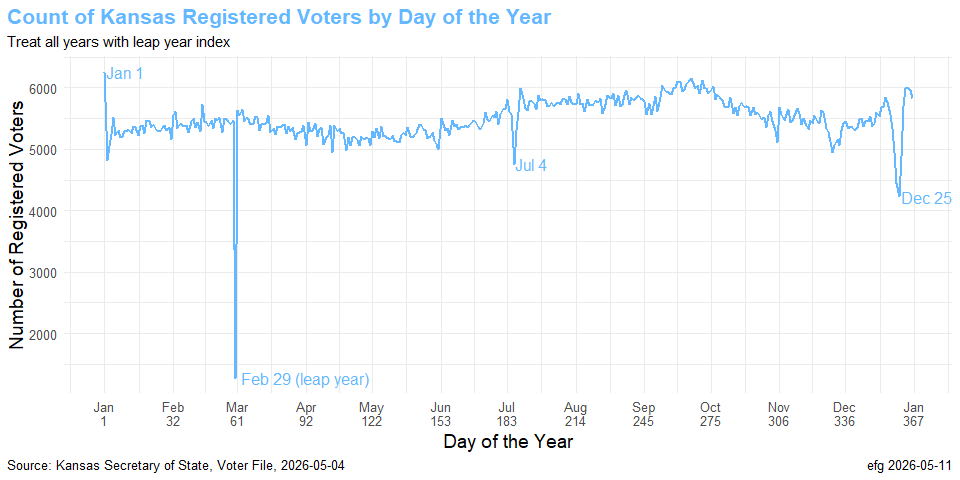

```r
ggplot(
        countsByDay,
        aes(x = DayOfLeapYear,
            y = Count)
      )                          +
geom_line(size  = 1,
          color = "steelblue1")  +
scale_x_continuous(
                    breaks = dayOfYearBreaks,
                    labels = dayOfYearLabels
                  )        +

annotate(
          "text",
           x = c(1, 60, 186, 360),
           y = countsByDay$Count[c(1, 60, 186, 360)],
           size  = 12/.pt,
           label = c("Jan 1", "Feb 29 (leap year)", "Jul 4", "Dec 25"),
           color = "steelblue1",
           hjust = -0.05
        )                  +


labs(
      title    = "Count of Kansas Registered Voters by Day of the Year",
      subtitle = "Treat all years with leap year index",
      x = "Day of the Year",
      y = "Number of Registered Voters",
      caption = c(paste0("Source: ", plotCaptionLeftSoS),
                  plotCaptionRight)
    )
```

## 12.2 Jan 1 Density

### 12.2.1 County

```r
quantile(
          countsCounty$Jan1Percent,
          probs = c(0.00, 0.01, 0.05, 0.10, 0.25, 0.50,
                    0.75, 0.90, 0.95, 0.99, 1.00)
        )
```

```
     0%      1%      5%     10%     25%     50%     75%     90%     95%     99%
0.00000 0.04984 0.11320 0.16620 0.20400 0.24700 0.31100 0.35120 0.40860 1.07220
   100%
1.92800
```

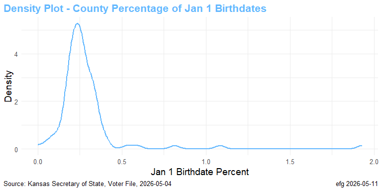

```r
ggplot(countsCounty, aes(x = Jan1Percent)) +
  geom_density(size  = 1,
               color = "steelblue1")       +
  labs(
        title   = "Density Plot - County Percentage of Jan 1 Birthdates",
        x       = "Jan 1 Birthdate Percent",
        y       = "Density",
        caption = c(paste0("Source: ", plotCaptionLeftSoS),
                  plotCaptionRight)
      )
```

### 12.2.2 Precinct

```r
quantile(
          countsPrecinct$Jan1Percent,
          probs = c(0.00, 0.01, 0.05, 0.10, 0.25, 0.50,
                    0.75, 0.90, 0.95, 0.99, 1.00)
        )
```

```
       0%        1%        5%       10%       25%       50%       75%       90%
  0.00000   0.00000   0.00000   0.00000   0.00000   0.07450   0.35175   0.67500
      95%       99%      100%
  1.02000   2.79815 100.00000
```

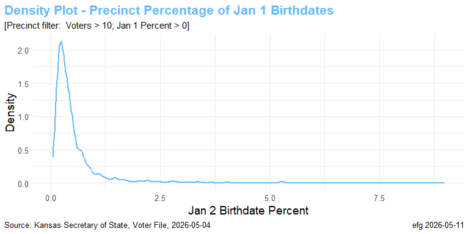

```r
countsPrecinct                |>
  filter(Voters      > 10,
         Jan1Percent > 0)     |>
  ggplot(aes(x = Jan1Percent))             +
    geom_density(size  = 1,
                 color = "steelblue1")     +
    labs(
          title =    "Density Plot - Precinct Percentage of Jan 1 Birthdates",
          subtitle = "[Precinct filter:  Voters > 10; Jan 1 Percent > 0]",
          x     = "Jan 2 Birthdate Percent",
          y     = "Density",
           caption = c(paste0("Source: ", plotCaptionLeftSoS),
                  plotCaptionRight)
        )
```

# 13 Epilog

## 13.1

Processing time: 253.5 secs

2026-05-11 2209